# Analysis of random sample

MaryJo Webster, Brandon Stahl, Jennifer Bjorhus

Last updated: 2018-12-27

# Cases included

This analysis is of a random sample of about half the cases from Minneapolis, plus all the cases from other agencies that we requested data from. Here are the number of cases included from each department. This is in order to downplay the influence of the large share of Mpls cases

| dept | Number_cases |
| --- | --- |
| Minneapolis | 200 |
| Anoka | 124 |
| St. Paul | 120 |
| Duluth | 112 |
| Brooklyn Park | 74 |
| Rochester | 58 |
| Mankato | 54 |
| St. Cloud | 49 |
| Wright County | 39 |
| Itasca | 28 |
| St. Louis County | 25 |
| Cass County | 21 |
| Brooklyn Center | 20 |
| Bloomington | 17 |
| Moorhead | 17 |
| Grand Rapids | 11 |
| U-Minnesota | 8 |
| Brainerd | 7 |
| Shakopee | 7 |
| Total | 991 |

# Analysis results

## Assigned to investigators

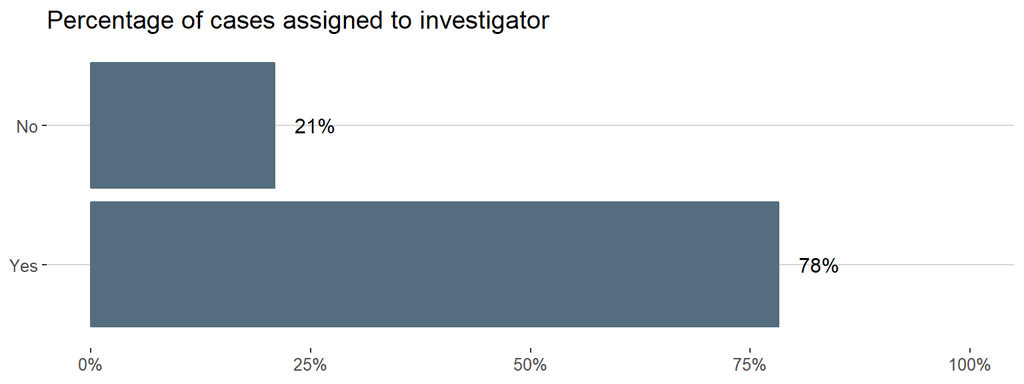

## Percent of cases sent for prosecution

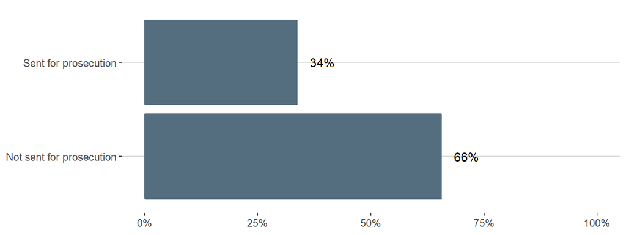

## Percent of cases where charges were filed

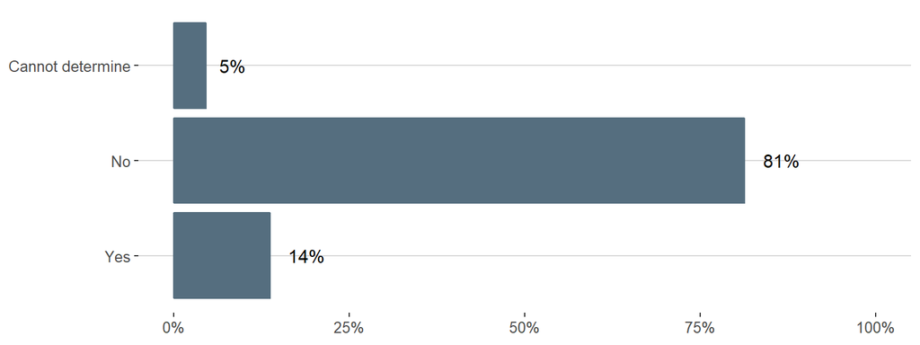

## Percent of cases resulting in conviction

Less than 1 in 10 of the cases we reviewed resulted in conviction.

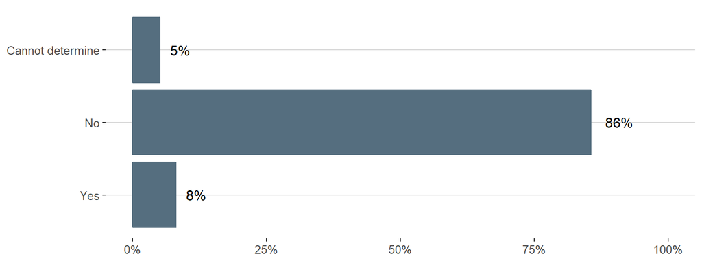

# Case investigations

The charts below look at how often investigators took basic policing steps in the cases we reviewed.

A recommended best practice is for investigators to conduct a more thorough interview after the victim makes an initial report to the officer responding to the initial call.

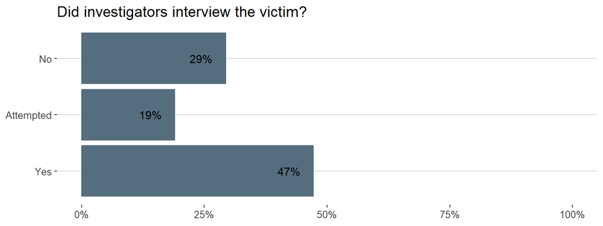

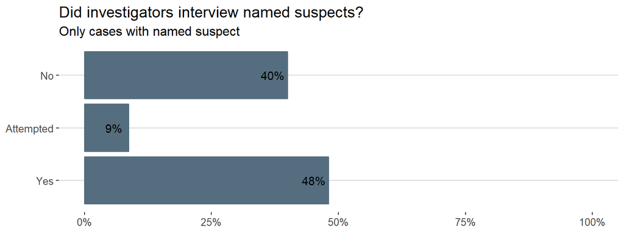

When reviewing cases, we looked for indications of evidence that could’ve been collected but there was no documentation in the report that it was. This might have included DNA, clothing or bed sheets, surveillance video or cell phone data.

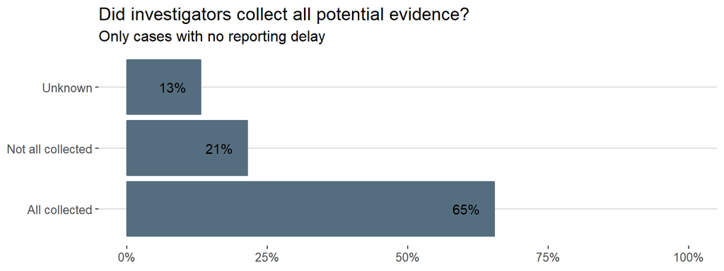

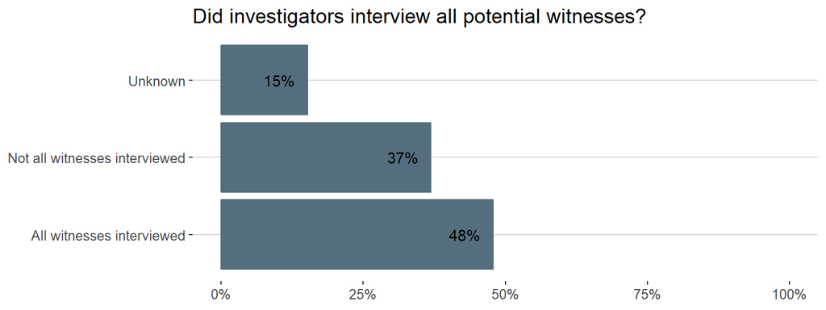

# Cases not sent for prosecution

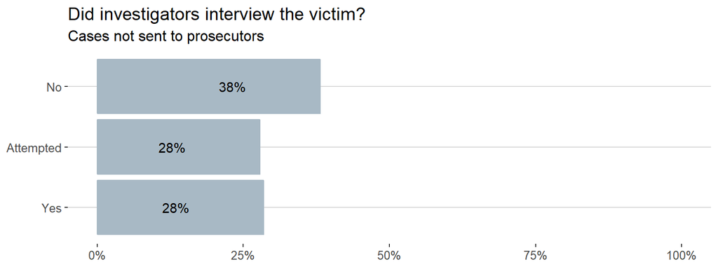

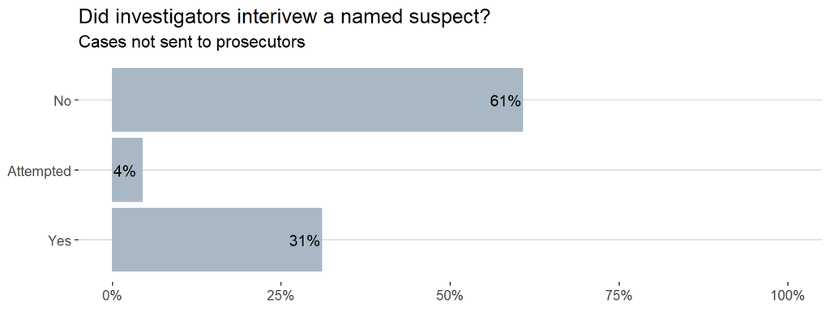

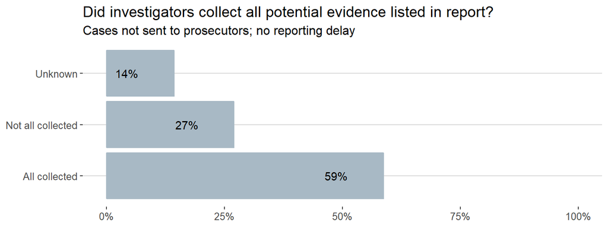

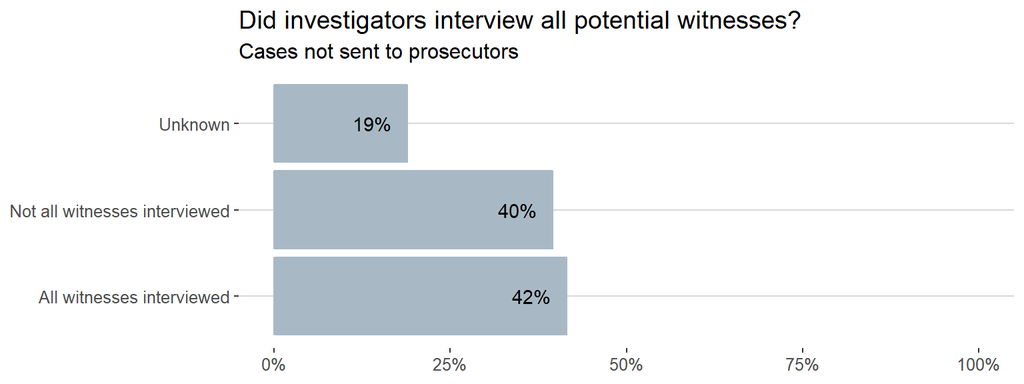

# Victim involvement

About one-third of victims either choose to no longer cooperate in an investigation or police are unable to reach them later in the investigation.

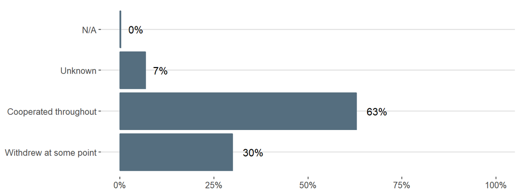

When a victim stays involved in the investigation, the case is far more likely to be sent to prosecutors.

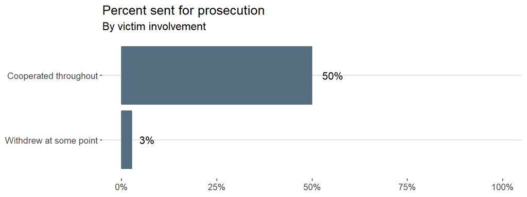

And we’ve only found 1 case that resulted in a conviction after the victim dropped out.

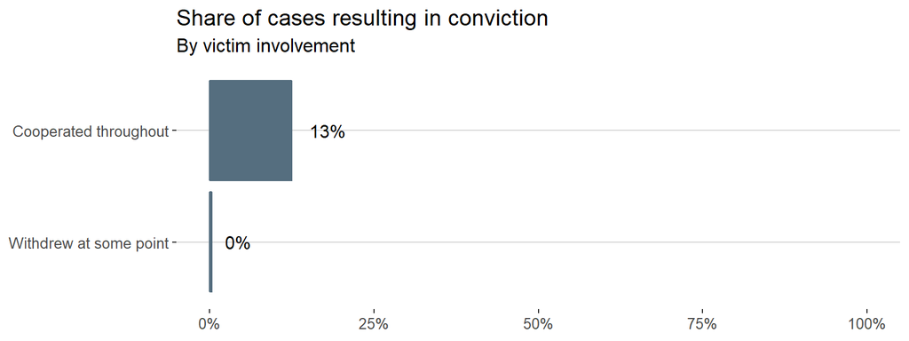